# U.S Mass Shootings Analysis

Tianyi Wang; Xiaoqian Sun; Yeon Kyung Chung; Yon Ho Cheong

11/19/2017

##### **Mass Shootings Data Analysis**

According to our dataset, it is clear to see mass shootings in the United States have unfortunately become a disturbing trend that seems to be on the rise. During 2012 to 2017, there have 190 mass shootings out of the total of 324(1966-2017) which it is around 58.6%.Besides the original dataset, we added several related datasets to enrich analysis for independent variables: the number of total federal firearms licensees, number of internet users, gross domestic product(GDP) and the number of drugs arrested, divided the mass shootings by regions and U.S. population. Through these variables we can make the different models to analysis the mass shootings.

Although all the important variables have been broadly found in research, in this project, Since the majority of our dataset happens after 2000, so we decided to target the data which starts from the year 2000 to do the analysis. In this report, we are going to contribute different independent and dependent variables from our dataset in order to find the relationship among these mass shootings in the United States.

**1. How did you develop your question and what relevant research has already been completed on this topic?**

There are some of the relevant research has already been completed on mass shootings such as mass shooting with media coverage; mass shootings and mental illness; mass shootings and psychotropic drugs. In our dataset, we want to learn which national trends influence the mass shooting most, and we want to figure out how to minimize the number of mass shooting. We try to use EDA process to explore, learn about and get an outline of the dataset, and even to find out whether there is other information we need to complete the research. At first, we try to find the pattern of mass shooting and find out the safest place to live in, but we cannot make any prediction from the results. Then we decide to find the national trends which contribute the most to the number of mass shootings. We developed our datasets and come out our final question: how to minimize the number of total victims in the mass shooting?

**2. How did you gather and prepare the data for analysis?**

At the beginning, we were trying to find the pattern of mass shooting, but we find out that it is not possible to make any prediction and promotion from the original dataset. That’s the reason that we started collecting other information from different government websites. We created variables such as GDP, population, drug arrested, and firearms license.

Since the most of the mass shootings happened after 2000, so we choose the dataset with our variables. All of our variables are numeric, so we are possible to use linear regression to study the relationship between these factors. It will help us to find the national trends which might contribute most to the number of mass shootings in the United States.

**3. How did you select and determine the correct regression model to answer your question?**

We considered all possible model, such as Linear regression, Logistic regression, KNN, K-Mean and Decision Trees. However, our data is all continuous variables and the dependent variable is Total number of Victims. For the reason, my team decided “Linear Regression Model” to use our answer.

**4. How reliable are your results?**

Our dependent variable is Total number of victims. As linear regress model assumption, the dependent variable should be a normal distribution. Yet, the predict variable is not a normal distribution. So, we checked residuals and it is a normal distribution. Also, based on linear regression model assumptions, independent variables should not be correlated. Our independent variables are correlated. That’s the reason we made 4 individual linear regression models. Our team used in-place predict and RMSE was high value. Thus, our models do not a perfect model.

**6. What additional information or analysis might improve your model results or work to control limitations?**

In our mass shooting dataset, mass shooting is increased dramatically after 2015. It hard for us to analysis the exact reason for the mass shooting because we only have a couple of years data. In addition, some of the data is hard to find and track. For example, the number of internet users and drug arrest data, we only have the years after 2000. This quality of this dataset also needs to updates too. In the original dataset, over the half of the data in mental health are unclear. There also need to put the reason why the mass killers did that so that we can focus on specific areas to prevent these mass shooting.

**Conclusion**：

To sum up, Federal firearms licensees, number of internet users, U.S. population and number of shootings are significant to the mass shootings. It is challenging for Mass shootings in the United States because it seems to have different views. Some of the young people think having a gun will solve their problem. In our dataset, there have young individuals that are enlightened or inspired to copy off of another mass killers. It is hard to track the data for these copycat crimes. In addition, gun control always is a big problem in the United States. Some areas may have problems with security in making it easy for anyone with a concealed weapon to enter in. It brings another question for the argument: is it too easy for American to get a gun? Excepts these, there are still lots of reasons might cause the mass shooting such as mental health and the media contagion effect. It is the reality that younger audiences are being exposed to. In the meantime, we need to focus on teaching people how to stay safe and how to get help for the mental disease which might help to prevent other mass shootings.

> Mass Shootings Data Analysis in R

##### 1. Read Data and remove outliers

##### 2. EDA

- Check Normal distribution: Histogram
- Correlation

##### 3. Make a Model fotr the dataset

- **Dependent variable(y)** : Total victims
- **Independet variables(x)** : number of Mass Shooting, Population, GDP number of Internet Users, number of Firearms Licensees
- Make a model: Linear regression
- Measure the error rate of a regression model: RMSE

###### =================Load & Prep Dataset==========================

```r
library(dplyr)
library(car)
```

```r
library(fmsb)
library(corrplot)
library(RColorBrewer)
library(gdata)
yeardata <- data.frame(read.xls("Mass Shootings Dataset.xlsx",
                       sheet = "Mass Shootings Yearly", header = TRUE))
head(yeardata)
```

```
##   Year No..Mass.Shooting Total.victims Real.GDP US.Population
## 1 2016                69           455    17157     324304407
## 2 2015                67           395    16472     322060152
## 3 2014                14           112    16013     319849022
## 4 2013                16           101    15612     317474097
## 5 2012                15           204    15355     315219776
## 6 2011                 6            65    15021     312917134
##   Internet.Users Drug.Arrested No..In.WEST No..In.MIDWEST No..In.NORTHEAST
## 1      286942362       1572579          12             12                7
## 2      283712407       1488707           8             11               12
## 3      279070327       1561231           7              0                1
## 4      267028444       1501043           7              2                3
## 5      249635976       1552432           5              3                2
## 6      217828119       1531251           2              1                1
##   No..In.SOUTH Federal.Firearms.Licensees.Total Firearms.Imports
## 1           36                           137464          5137771
## 2           36                           139840          3930211
## 3            6                           141116          3625268
## 4            4                           139244          5539539
## 5            4                           130956          4844590
## 6            2                           123587          3252404
##   Firearms.Manufactured
## 1                    NA
## 2               9358661
## 3               9050626
## 4              10844792
## 5               8578610
## 6               6541886
```

```r
str(yeardata)
```

```
## 'data.frame':    17 obs. of  14 variables:
##  $ Year                            : int  2016 2015 2014 2013 2012 2011 2010 2009 2008 2007 ...
##  $ No..Mass.Shooting               : int  69 67 14 16 15 6 2 8 6 10 ...
##  $ Total.victims                   : int  455 395 112 101 204 65 17 115 57 123 ...
##  $ Real.GDP                        : int  17157 16472 16013 15612 15355 15021 14784 14419 14830 14874 ...
##  $ US.Population                   : int  324304407 322060152 319849022 317474097 315219776 312917134 310599079 307006550 304374846 301579895 ...
##  $ Internet.Users                  : int  286942362 283712407 279070327 267028444 249635976 217828119 222150226 218134692 225310126 226241965 ...
##  $ Drug.Arrested                   : int  1572579 1488707 1561231 1501043 1552432 1531251 1638846 1663582 1702537 1841182 ...
##  $ No..In.WEST                     : int  12 8 7 7 5 2 0 3 1 5 ...
##  $ No..In.MIDWEST                  : int  12 11 0 2 3 1 0 0 3 3 ...
##  $ No..In.NORTHEAST                : int  7 12 1 3 2 1 1 1 0 1 ...
##  $ No..In.SOUTH                    : int  36 36 6 4 4 2 1 4 2 1 ...
##  $ Federal.Firearms.Licensees.Total: int  137464 139840 141116 139244 130956 123587 118487 115395 112943 108933 ...
##  $ Firearms.Imports                : int  5137771 3930211 3625268 5539539 4844590 3252404 2839947 3607106 2606386 2743993 ...
##  $ Firearms.Manufactured           : int  NA 9358661 9050626 10844792 8578610 6541886 5459240 5555818 4498944 3922613 ...
```

```r
Year <- yeardata$Year
NoShooting <- yeardata$No..Mass.Shooting
TotalVictims <- yeardata$Total.victims
Gdp <- yeardata$Real.GDP
Population <- yeardata$US.Population
RegionWest <- yeardata$No..In.WEST
RegionMidWest <- yeardata$No..In.MIDWEST
InternetUsers <- yeardata$Internet.Users
RegionNorthEast <- yeardata$No..In.NORTHEAST
RegionSouth <- yeardata$No..In.SOUTH
FirearmsLicensees <- yeardata$Federal.Firearms.Licensees.Total
FirearmsImports <- yeardata$Firearms.Imports

# ====== subset dataset
# subset data after the year of 2012 - 2017

yeardata_after2012 = data.frame(subset(yeardata, `Year` >= 2012 ))
str(yeardata_after2012)
```

```
## 'data.frame':    5 obs. of  14 variables:
##  $ Year                            : int  2016 2015 2014 2013 2012
##  $ No..Mass.Shooting               : int  69 67 14 16 15
##  $ Total.victims                   : int  455 395 112 101 204
##  $ Real.GDP                        : int  17157 16472 16013 15612 15355
##  $ US.Population                   : int  324304407 322060152 319849022 317474097 315219776
##  $ Internet.Users                  : int  286942362 283712407 279070327 267028444 249635976
##  $ Drug.Arrested                   : int  1572579 1488707 1561231 1501043 1552432
##  $ No..In.WEST                     : int  12 8 7 7 5
##  $ No..In.MIDWEST                  : int  12 11 0 2 3
##  $ No..In.NORTHEAST                : int  7 12 1 3 2
##  $ No..In.SOUTH                    : int  36 36 6 4 4
##  $ Federal.Firearms.Licensees.Total: int  137464 139840 141116 139244 130956
##  $ Firearms.Imports                : int  5137771 3930211 3625268 5539539 4844590
##  $ Firearms.Manufactured           : int  NA 9358661 9050626 10844792 8578610
```

```r
# ====== Mass Shootings Dataset
shootingdata <- data.frame(read.xls("Mass Shootings Dataset.xlsx",
                       sheet = "Mass Shootings Dataset", header = TRUE))
head(shootingdata)
```

```
##   S.                               Title               Location Year
## 1  1          Texas church mass shooting Sutherland Springs, TX 2017
## 2  2 Walmart shooting in suburban Denver           Thornton, CO 2017
## 3  3     Edgewood businees park shooting           Edgewood, MD 2017
## 4  4       Las Vegas Strip mass shooting          Las Vegas, NV 2017
## 5  5          San Francisco UPS shooting      San Francisco, CA 2017
## 6  6   Pennsylvania supermarket shooting        Tunkhannock, PA 2017
##   Real.GDP US.Population Total.victims Latitude  Longitude
## 1   17,157   326,263,971            46 29.27311  -98.05659
## 2   17,157   326,263,971             3 39.87030 -104.97934
## 3   17,157   326,263,971             6 39.41868  -76.29204
## 4   17,157   326,263,971           585 36.18127 -115.13413
## 5   17,157   326,263,971             5 37.75458 -122.44243
## 6   17,157   326,263,971             3 41.53872  -75.94843
##                     Regions Internet.Users Drug.Arrested
## 1  South,West South Central    320,059,368
## 2             West,Mountain    320,059,368
## 3      South,South Atlantic    320,059,368
## 4             West,Mountain    320,059,368
## 5              West,Pacific    320,059,368
## 6 Northeast,Middle Atlantic    320,059,368
```

###### ========================EDA===================================

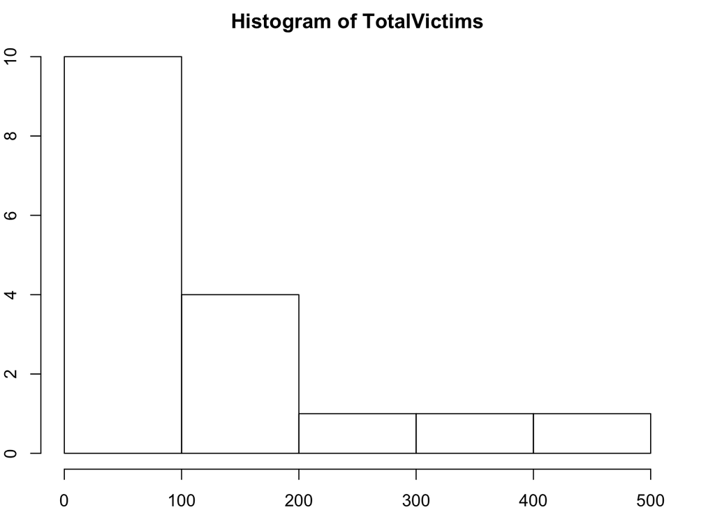

```r
par(mar = rep(2, 4))

# Total Victims: Dependent variable
hist(TotalVictims)
```

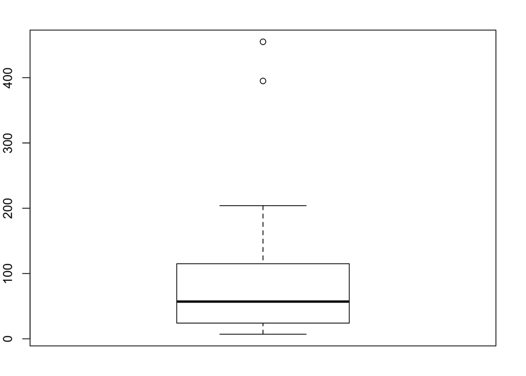

```r
boxplot(TotalVictims)
```

```r
# Remove outliers of Total Victims from 2015 - 2017
yeardata_RemoveOutliers <- yeardata[3:length(yeardata), ]
yeardata_RemoveOutliers
```

```
##    Year No..Mass.Shooting Total.victims Real.GDP US.Population
## 3  2014                14           112    16013     319849022
## 4  2013                16           101    15612     317474097
## 5  2012                15           204    15355     315219776
## 6  2011                 6            65    15021     312917134
## 7  2010                 2            17    14784     310599079
## 8  2009                 8           115    14419     307006550
## 9  2008                 6            57    14830     304374846
## 10 2007                10           123    14874     301579895
## 11 2006                 7            49    14614     298593212
## 12 2005                 3            31    14234     295753151
## 13 2004                 2            19    13774     293045739
## 14 2003                 3            24    13271     290326418
##    Internet.Users Drug.Arrested No..In.WEST No..In.MIDWEST
## 3       279070327       1561231           7              0
```

[output cut: 37 more lines]

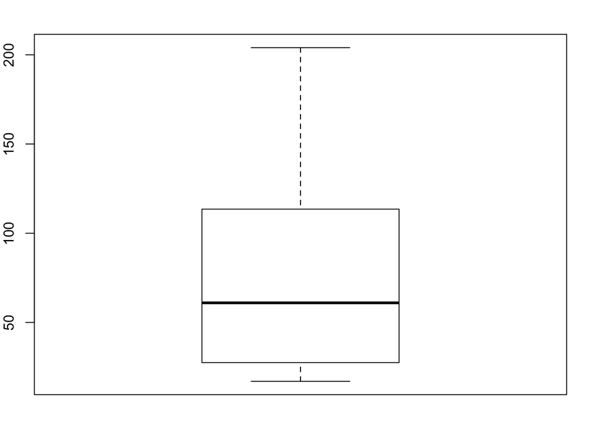

```r
boxplot(yeardata_RemoveOutliers$Total.victims)
```

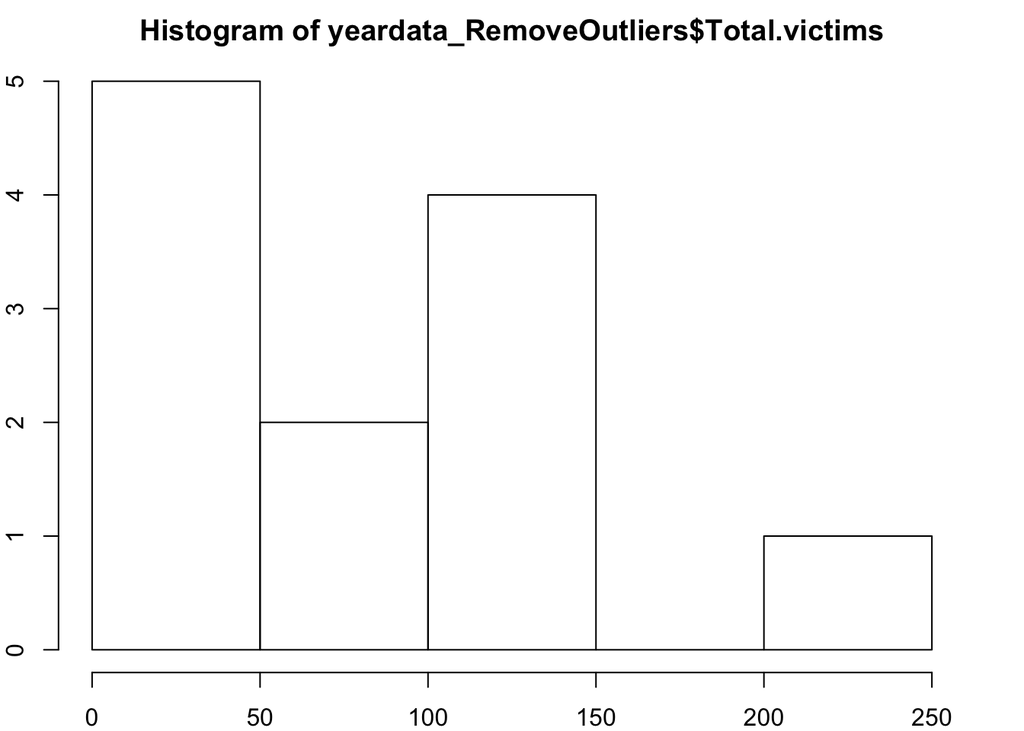

```r
hist(yeardata_RemoveOutliers$Total.victims)
```

```r
# Correlation between independent variables
cordata <- data.frame(TotalVictims, NoShooting, Population, InternetUsers, FirearmsLicensees)
shootingcor <- cor(cordata)
shootingcor
```

```
##                   TotalVictims NoShooting Population InternetUsers
## TotalVictims         1.0000000  0.9708664  0.7276756     0.7334802
## NoShooting           0.9708664  1.0000000  0.6736930     0.6872774
## Population           0.7276756  0.6736930  1.0000000     0.9611164
## InternetUsers        0.7334802  0.6872774  0.9611164     1.0000000
## FirearmsLicensees    0.7171038  0.6885425  0.9409969     0.8980841
##                   FirearmsLicensees
## TotalVictims              0.7171038
## NoShooting                0.6885425
## Population                0.9409969
## InternetUsers             0.8980841
## FirearmsLicensees         1.0000000
```

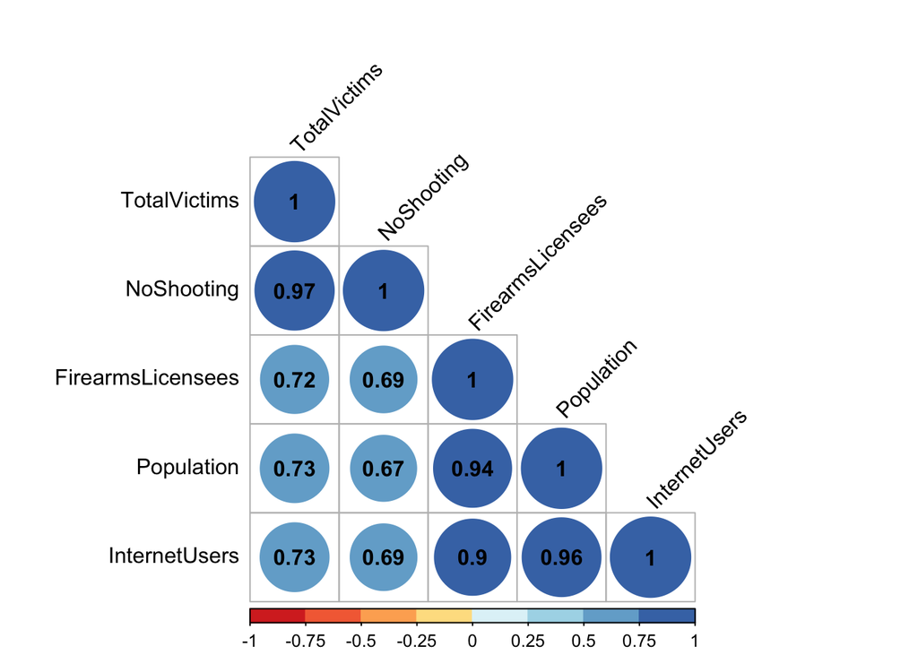

```r
corrplot(shootingcor, type="lower", addCoef.col= "black",
         order="hclust",  col=brewer.pal(n=8, name="RdYlBu"), tl.col="black",tl.srt=45)
```

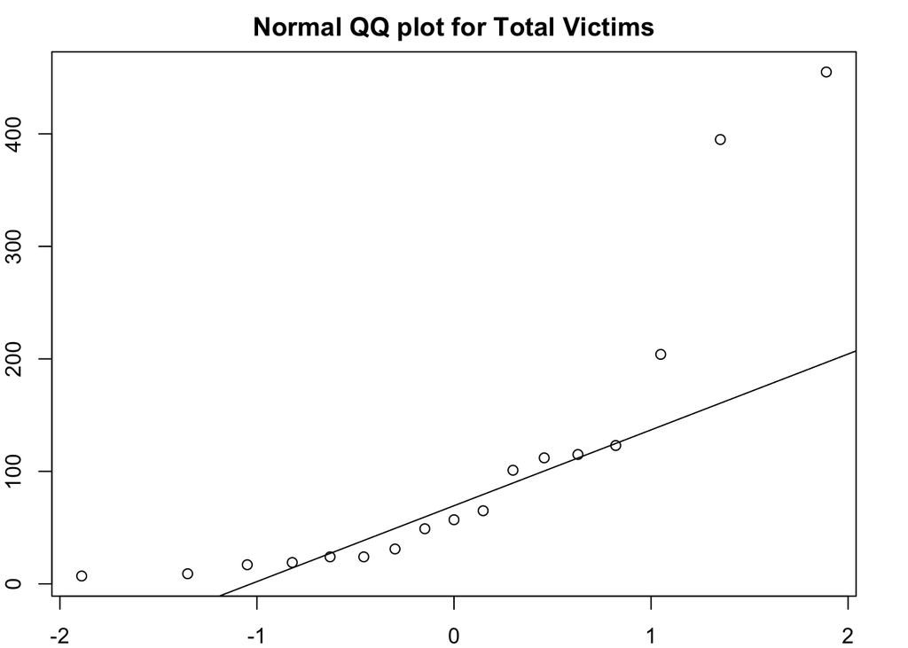

```r
# Check the Dependent variable is "Normal Distribution" or not
lm <- lm(TotalVictims~NoShooting, yeardata)
qqnorm(TotalVictims, main="Normal QQ plot for Total Victims")
qqline(TotalVictims)
```

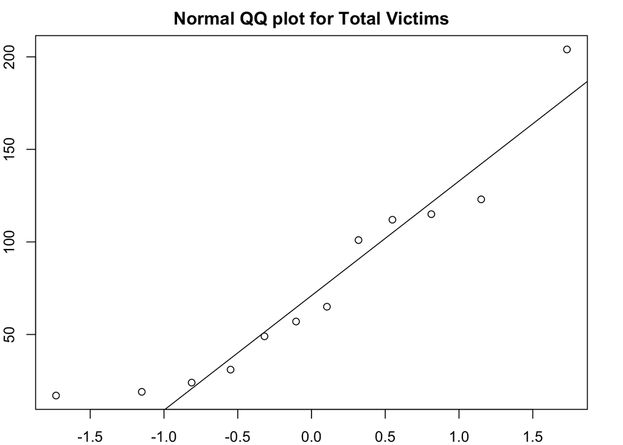

```r
lm <- lm(yeardata_RemoveOutliers$Total.victims~yeardata_RemoveOutliers$No..Mass.Shooting, yeardata_RemoveOutliers)
qqnorm(yeardata_RemoveOutliers$Total.victims, main="Normal QQ plot for Total Victims")
qqline(yeardata_RemoveOutliers$Total.victims)
```

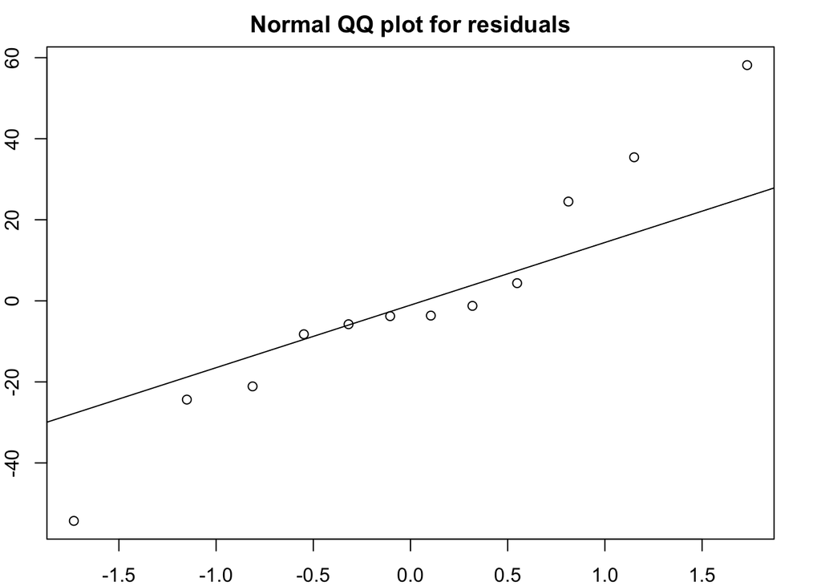

```r
qqnorm(lm$residuals, main="Normal QQ plot for residuals")
qqline(lm$residuals)
```

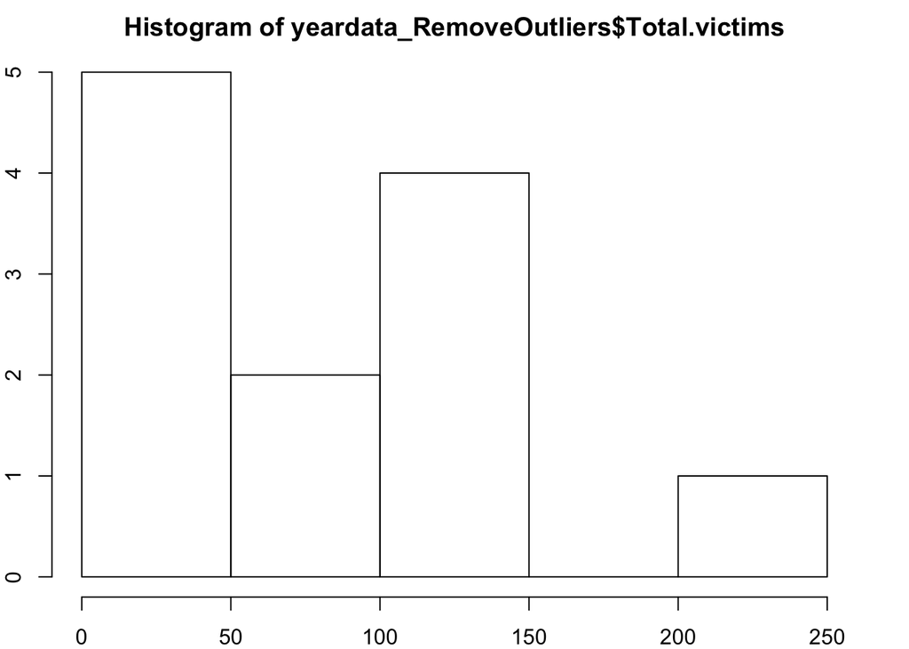

```r
hist(yeardata_RemoveOutliers$Total.victims)
```

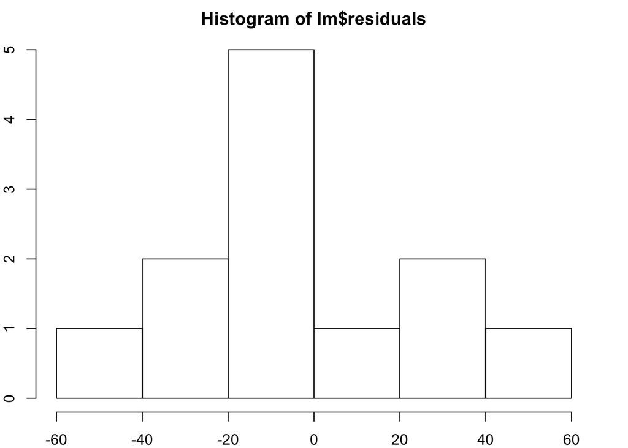

```r
hist(lm$residuals)
```

```r
shapiro.test(lm$residuals)
```

```
##
##  Shapiro-Wilk normality test
##
## data:  lm$residuals
## W = 0.95401, p-value = 0.6962
```

```r
shapiro.test(yeardata_RemoveOutliers$Total.victim)
```

```
##
##  Shapiro-Wilk normality test
##
## data:  yeardata_RemoveOutliers$Total.victim
## W = 0.89481, p-value = 0.136
```

###### ==================Linear Regression==========================

```r
# Create Model for the dataset: using Linear regression model
# Total victims: dependent variable
set.seed(5)
lm_model <- lm(TotalVictims~Population+NoShooting+InternetUsers+FirearmsLicensees,  data = yeardata)
summary(lm_model)
```

```
##
## Call:
## lm(formula = TotalVictims ~ Population + NoShooting + InternetUsers +
##     FirearmsLicensees, data = yeardata)
##
## Residuals:
##     Min      1Q  Median      3Q     Max
## -40.813 -15.507  -8.041  10.726  79.048
##
## Coefficients:
##                     Estimate Std. Error t value Pr(>|t|)
## (Intercept)       -6.601e+02  6.324e+02  -1.044    0.317
## Population         2.846e-06  2.823e-06   1.008    0.333
## NoShooting         5.617e+00  5.453e-01  10.299  2.6e-07 ***
## InternetUsers     -9.076e-08  6.264e-07  -0.145    0.887
## FirearmsLicensees -1.326e-03  1.688e-03  -0.786    0.447
## ---
## Signif. codes:  0 '***' 0.001 '**' 0.01 '*' 0.05 '.' 0.1 ' ' 1
##
## Residual standard error: 32.26 on 12 degrees of freedom
## Multiple R-squared:  0.9548, Adjusted R-squared:  0.9398
## F-statistic: 63.43 on 4 and 12 DF,  p-value: 5.709e-08
```

```r
### According to the results, our Independent variables are related to each other, so we had to try different models.
cor(Population, NoShooting)
```

```
## [1] 0.673693
```

```r
cor(InternetUsers+FirearmsLicensees, NoShooting)
```

```
## [1] 0.6872991
```

```r
####### Create a Funciton: Predict and Evaluate the Model(RMSE)
prec_func <- function(linear_model, original_data){
  #--- Predict In-place
  predictions <- predict(linear_model, yeardata)
  head(predictions)
  lm_shooting_pred <- data.frame(predictions,TotalVictims)

  lm_shooting_pred <- mutate(lm_shooting_pred, TotalVictims-predictions)
  names(lm_shooting_pred) <- c("prediction","totalvictims","error")
  print(head(lm_shooting_pred))
  #print(lm_shooting_pred$error)

  #--- Evaluate the model: RMSE
  mse <- data.frame(mean((lm_shooting_pred$error)^2))
  rmse_shootingestate <- sqrt(mse)
  #names(rmse_shootingestate) <- c("RMSE")
  print(rmse_shootingestate)
  print(VIF(linear_model))
}

# Make a model, Predict and Evalute the model
lm_model <- lm(TotalVictims~Population,  data = yeardata)
summary(lm_model)
```

```
##
## Call:
## lm(formula = TotalVictims ~ Population, data = yeardata)
##
## Residuals:
##      Min       1Q   Median       3Q      Max
## -135.824  -51.874   -9.878   33.861  205.402
##
## Coefficients:
##               Estimate Std. Error t value Pr(>|t|)
## (Intercept) -2.040e+03  5.229e+02  -3.902  0.00142 **
## Population   7.061e-06  1.719e-06   4.109  0.00093 ***
## ---
## Signif. codes:  0 '***' 0.001 '**' 0.01 '*' 0.05 '.' 0.1 ' ' 1
##
## Residual standard error: 93.12 on 15 degrees of freedom
## Multiple R-squared:  0.5295, Adjusted R-squared:  0.4981
## F-statistic: 16.88 on 1 and 15 DF,  p-value: 0.0009296
```

```r
# call the funciton for prediction and evaluation
prec_func(lm_model, yeardata)
```

```
##   prediction totalvictims      error
## 1   249.5985          455  205.40152
## 2   233.7516          395  161.24840
## 3   218.1386          112 -106.13862
## 4   201.3691          101 -100.36906
## 5   185.4511          204   18.54889
## 6   169.1919           65 -104.19195
##   mean..lm_shooting_pred.error..2.
## 1                         87.47133
## [1] 2.125451
```

```r
lm_model2 = lm(TotalVictims~NoShooting,  data = yeardata)
summary(lm_model2)
```

```
##
## Call:
## lm(formula = TotalVictims ~ NoShooting, data = yeardata)
##
## Residuals:
##     Min      1Q  Median      3Q     Max
## -35.224 -18.144 -11.144   5.543  89.840
##
## Coefficients:
##             Estimate Std. Error t value Pr(>|t|)
## (Intercept)  22.9876     9.5097   2.417   0.0288 *
## NoShooting    6.0782     0.3873  15.692 1.03e-10 ***
## ---
## Signif. codes:  0 '***' 0.001 '**' 0.01 '*' 0.05 '.' 0.1 ' ' 1
##
## Residual standard error: 32.53 on 15 degrees of freedom
## Multiple R-squared:  0.9426, Adjusted R-squared:  0.9388
## F-statistic: 246.2 on 1 and 15 DF,  p-value: 1.025e-10
```

```r
# call the funciton for prediction and evaluation
prec_func(lm_model2, yeardata)
```

```
##   prediction totalvictims      error
## 1  442.38054          455  12.619465
## 2  430.22422          395 -35.224218
## 3  108.08181          112   3.918189
## 4  120.23813          101 -19.238129
## 5  114.15997          204  89.840030
## 6   59.45654           65   5.543458
##   mean..lm_shooting_pred.error..2.
## 1                         30.55742
## [1] 17.41603
```

```r
lm_model3 <- lm(TotalVictims~InternetUsers, data = yeardata)
summary(lm_model3)
```

```
##
## Call:
## lm(formula = TotalVictims ~ InternetUsers, data = yeardata)
##
## Residuals:
##      Min       1Q   Median       3Q      Max
## -119.886  -44.128   -7.322   31.429  207.251
##
## Coefficients:
##                 Estimate Std. Error t value Pr(>|t|)
## (Intercept)   -3.305e+02  1.069e+02  -3.092 0.007435 **
## InternetUsers  2.015e-06  4.822e-07   4.179 0.000806 ***
## ---
## Signif. codes:  0 '***' 0.001 '**' 0.01 '*' 0.05 '.' 0.1 ' ' 1
##
## Residual standard error: 92.28 on 15 degrees of freedom
## Multiple R-squared:  0.538,  Adjusted R-squared:  0.5072
## F-statistic: 17.47 on 1 and 15 DF,  p-value: 0.0008058
```

```r
# call the funciton for prediction and evaluation
prec_func(lm_model3, yeardata)
```

```
##   prediction totalvictims      error
## 1   247.7492          455  207.25076
## 2   241.2404          395  153.75960
## 3   231.8859          112 -119.88593
## 4   207.6198          101 -106.61976
## 5   172.5714          204   31.42863
## 6   108.4738           65  -43.47385
##   mean..lm_shooting_pred.error..2.
## 1                         86.67933
## [1] 2.16447
```

```r
lm_model4 <- lm(Total.victims~FirearmsLicensees, data = yeardata)
summary(lm_model4)
```

```
##
## Call:
## lm(formula = Total.victims ~ FirearmsLicensees, data = yeardata)
##
## Residuals:
##      Min       1Q   Median       3Q      Max
## -145.590  -18.277   -2.143   13.629  221.043
##
## Coefficients:
##                     Estimate Std. Error t value Pr(>|t|)
## (Intercept)       -6.556e+02  1.926e+02  -3.405  0.00392 **
## FirearmsLicensees  6.471e-03  1.624e-03   3.985  0.00120 **
## ---
## Signif. codes:  0 '***' 0.001 '**' 0.01 '*' 0.05 '.' 0.1 ' ' 1
##
## Residual standard error: 94.62 on 15 degrees of freedom
## Multiple R-squared:  0.5142, Adjusted R-squared:  0.4819
## F-statistic: 15.88 on 1 and 15 DF,  p-value: 0.001196
```

```r
# call the funciton for prediction and evaluation
prec_func(lm_model4, yeardata)
```

```
##   prediction totalvictims      error
## 1   233.9574          455  221.04264
## 2   249.3329          395  145.66710
## 3   257.5901          112 -145.59014
## 4   245.4761          101 -144.47607
## 5   191.8429          204   12.15714
## 6   144.1567           65  -79.15667
##   mean..lm_shooting_pred.error..2.
## 1                         88.87982
## [1] 2.058621
```

```r
lm_model5 <- lm(Total.victims~RegionMidWest+RegionNorthEast
                          +RegionSouth+RegionWest, data = yeardata)
summary(lm_model5)
```

```
##
## Call:
## lm(formula = Total.victims ~ RegionMidWest + RegionNorthEast +
##     RegionSouth + RegionWest, data = yeardata)
##
## Residuals:
##     Min      1Q  Median      3Q     Max
## -49.069 -11.811  -2.787   1.983  71.934
##
## Coefficients:
##                 Estimate Std. Error t value Pr(>|t|)
## (Intercept)       10.474     11.307   0.926  0.37249
## RegionMidWest     11.470      6.007   1.909  0.08039 .
## RegionNorthEast    1.740      5.378   0.324  0.75186
## RegionSouth        3.593      2.559   1.404  0.18574
## RegionWest        13.866      3.357   4.131  0.00139 **
## ---
## Signif. codes:  0 '***' 0.001 '**' 0.01 '*' 0.05 '.' 0.1 ' ' 1
##
## Residual standard error: 30.11 on 12 degrees of freedom
## Multiple R-squared:  0.9606, Adjusted R-squared:  0.9475
## F-statistic: 73.24 on 4 and 12 DF,  p-value: 2.512e-08
```

```r
#subset
attach(yeardata_after2012)
names(yeardata_after2012)
```

```
##  [1] "Year"                             "No..Mass.Shooting"
##  [3] "Total.victims"                    "Real.GDP"
##  [5] "US.Population"                    "Internet.Users"
##  [7] "Drug.Arrested"                    "No..In.WEST"
##  [9] "No..In.MIDWEST"                   "No..In.NORTHEAST"
## [11] "No..In.SOUTH"                     "Federal.Firearms.Licensees.Total"
## [13] "Firearms.Imports"                 "Firearms.Manufactured"
```

```r
lm_model_subset2 = lm(Total.victims~No..In.MIDWEST , data=yeardata_after2012)
summary(lm_model_subset2)
```

```
##
## Call:
## lm(formula = Total.victims ~ No..In.MIDWEST, data = yeardata_after2012)
##
## Residuals:
##      1      2      3      4      5
##  15.52 -15.40  21.42 -47.73  26.19
##
## Coefficients:
##                Estimate Std. Error t value Pr(>|t|)
## (Intercept)      90.584     24.425   3.709  0.03407 *
## No..In.MIDWEST   29.074      3.276   8.876  0.00302 **
## ---
## Signif. codes:  0 '***' 0.001 '**' 0.01 '*' 0.05 '.' 0.1 ' ' 1
##
## Residual standard error: 36.06 on 3 degrees of freedom
## Multiple R-squared:  0.9633, Adjusted R-squared:  0.9511
## F-statistic: 78.78 on 1 and 3 DF,  p-value: 0.003015
```

###### =================Plot Linear regression==========================

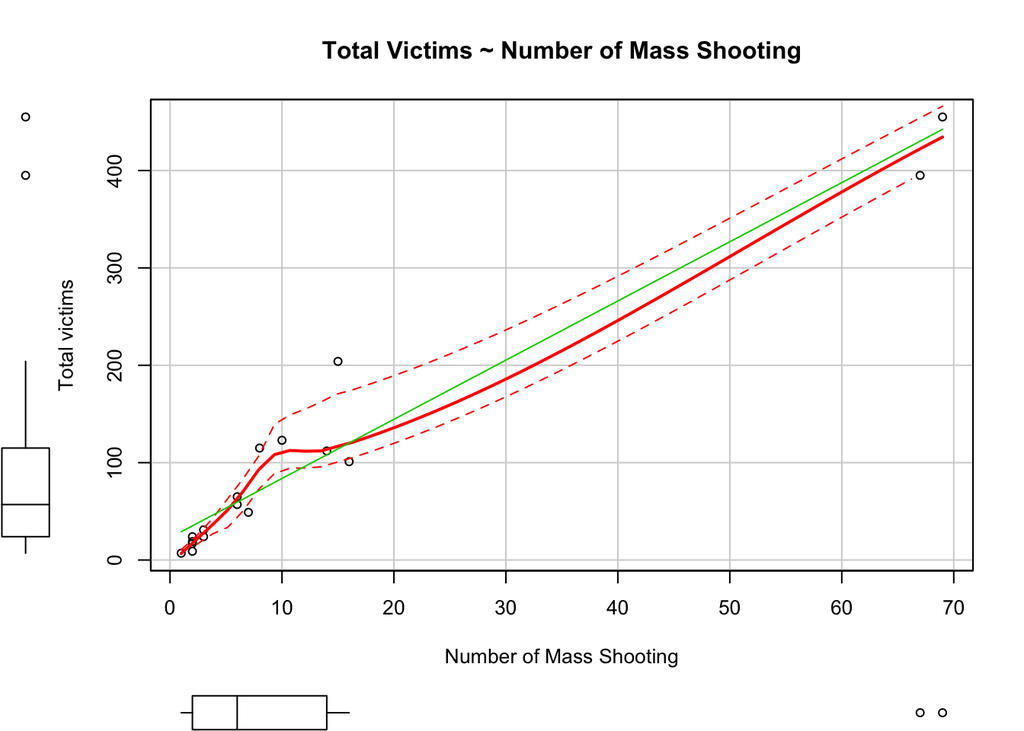

```r
#linear regression model: Total victims with the number of shootings

scatterplot(TotalVictims ~ NoShooting, data=yeardata,
    xlab="Number of Mass Shooting", ylab="Total victims",
   main="Total Victims ~ Number of Mass Shooting",
   labels=row.names(yeardata))
```

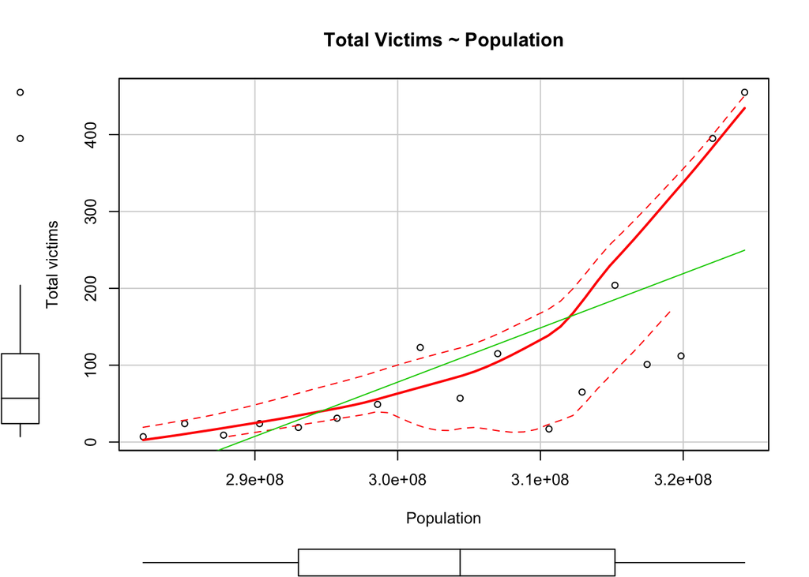

```r
#linear regression model: Total victims with population
scatterplot(TotalVictims ~ Population, data=yeardata,
    xlab="Population", ylab="Total victims",
   main="Total Victims ~ Population",
   labels=row.names(yeardata))
```

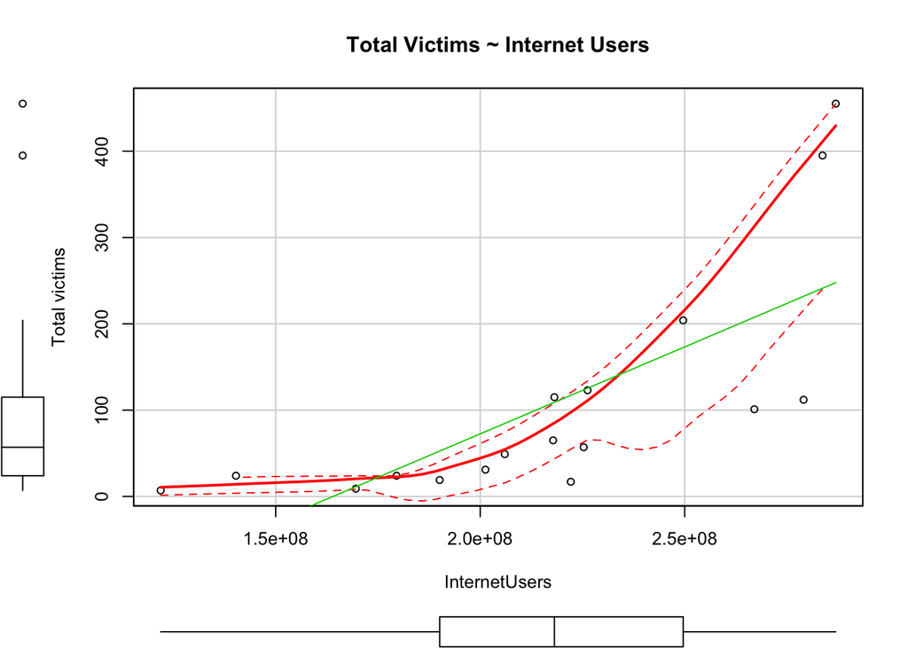

```r
#linear regression model: Total victims with the number of the internet users
scatterplot(TotalVictims ~ InternetUsers, data=yeardata,
    xlab="InternetUsers", ylab="Total victims",
   main="Total Victims ~ Internet Users",
   labels=row.names(yeardata))
```

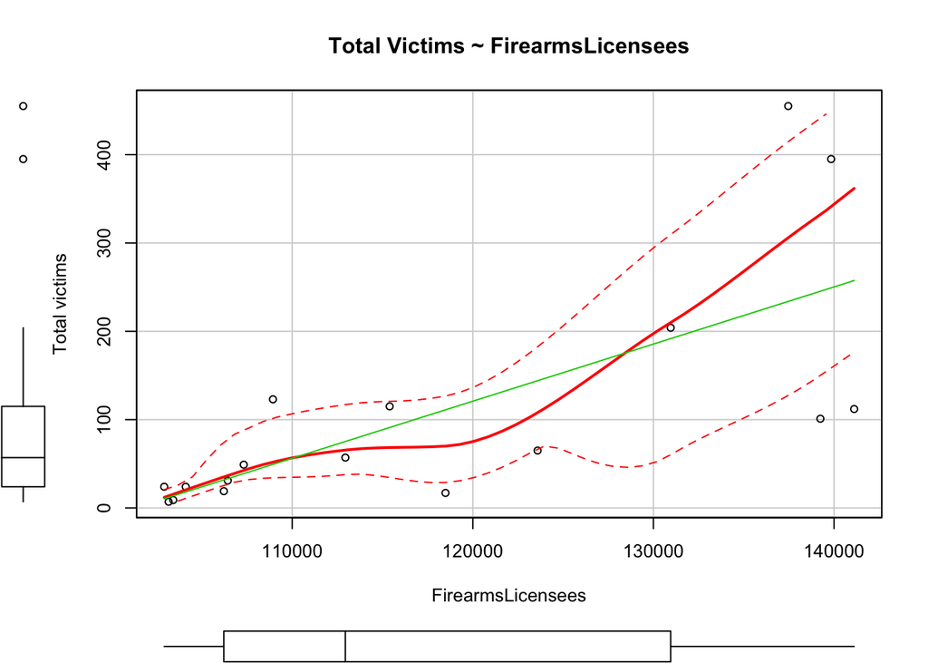

```r
#linear regression model: Total victims with the number of Firearms Licensees
scatterplot(TotalVictims ~ FirearmsLicensees, data=yeardata,
    xlab="FirearmsLicensees", ylab="Total victims",
   main="Total Victims ~ FirearmsLicensees",
   labels=row.names(yeardata))
```

```r
#linear regression line is in green
#The red lines are lOWESS (Locally Weighted Scatterplot Smoothing), which is used to create a smooth line through a timeplot or scatter plot. It would help you to check the relationship of variables and forecast the trends.
```

###### ==================Geo Map(leaflet)=======================================

```r
if(!require(leaflet)) install.packages("leaflet")
```

```r
library(leaflet)

###### Create a funciton: Make a Geo Map
MassShootingMap <- function(massshootingdata) {
    leaflet(data = massshootingdata) %>%
      addProviderTiles(providers$CartoDB.DarkMatter, group="Dark") %>%
      addProviderTiles(providers$CartoDB.Positron, group="Light") %>%
      addLayersControl(baseGroups=c('Dark','Light')) %>%
      addTiles() %>%
            addMarkers(~Longitude, ~Latitude,
                 clusterOptions = markerClusterOptions(),
                 popup = ~as.character(Title),
                 label = ~as.character(Location))
}

## Total Mass Shootings Geo map
# call a funciton to create GeoMap
MassShootingMap(shootingdata)
```

[interactive chart not shown]

```r
## 2015 Geo map
shootingdata_2015 <- subset(shootingdata, shootingdata$Year == 2015)
str(shootingdata_2015)
```

```
## 'data.frame':    67 obs. of  12 variables:
##  $ S.            : int  80 81 82 83 84 85 86 87 88 89 ...
##  $ Title         : Factor w/ 322 levels "49th Street Elementary School",..: 198 245 246 219 61 171 272 130 306 191 ...
##  $ Location      : Factor w/ 265 levels "Aiken, South Carolina",..: 184 216 216 46 48 159 243 115 257 179 ...
##  $ Year          : int  2015 2015 2015 2015 2015 2015 2015 2015 2015 2015 ...
##  $ Real.GDP      : Factor w/ 42 levels "10,175","10,561",..: 21 21 21 21 21 21 21 21 21 21 ...
##  $ US.Population : Factor w/ 42 levels "196,560,338",..: 40 40 40 40 40 40 40 40 40 40 ...
##  $ Total.victims : int  5 35 35 12 4 5 6 4 3 3 ...
##  $ Latitude      : num  41.3 34.1 34.1 38.8 40 ...
##  $ Longitude     : num  -96.1 -117.3 -117.3 -104.8 -83 ...
##  $ Regions       : Factor w/ 10 levels "Midwest,East North Central",..: 2 10 10 8 1 2 7 6 6 4 ...
##  $ Internet.Users: Factor w/ 19 levels "","121,869,116",..: 17 17 17 17 17 17 17 17 17 17 ...
##  $ Drug.Arrested : Factor w/ 24 levels "","1,089,500",..: 4 4 4 4 4 4 4 4 4 4 ...
```

```r
# call a funciton to create GeoMap
MassShootingMap(shootingdata_2015)
```

[interactive chart not shown]

```r
## 2016 Geo map
shootingdata_2016 <- subset(shootingdata, shootingdata$Year == 2016)
str(shootingdata_2016)
```

```
## 'data.frame':    69 obs. of  12 variables:
##  $ S.            : int  11 12 13 14 15 16 17 18 19 20 ...
##  $ Title         : Factor w/ 322 levels "49th Street Elementary School",..: 35 17 68 201 87 93 113 278 48 274 ...
##  $ Location      : Factor w/ 265 levels "Aiken, South Carolina",..: 27 13 56 187 74 76 99 12 40 122 ...
##  $ Year          : int  2016 2016 2016 2016 2016 2016 2016 2016 2016 2016 ...
##  $ Real.GDP      : Factor w/ 42 levels "10,175","10,561",..: 22 22 22 22 22 22 22 22 22 22 ...
##  $ US.Population : Factor w/ 42 levels "196,560,338",..: 41 41 41 41 41 41 41 41 41 41 ...
##  $ Total.victims : int  5 6 16 102 4 5 6 4 5 4 ...
##  $ Latitude      : num  48.5 30.5 32.8 28.5 38.7 ...
##  $ Longitude     : num  -122.3 -91.1 -96.8 -81.5 -90.3 ...
##  $ Regions       : Factor w/ 10 levels "Midwest,East North Central",..: 10 7 7 6 2 6 6 6 1 7 ...
##  $ Internet.Users: Factor w/ 19 levels "","121,869,116",..: 18 18 18 18 18 18 18 18 18 18 ...
##  $ Drug.Arrested : Factor w/ 24 levels "","1,089,500",..: 13 13 13 13 13 13 13 13 13 13 ...
```

```r
# call a funciton to create GeoMap
MassShootingMap(shootingdata_2016)
```

[interactive chart not shown]